# AGO Data Challenge

Nicholas Chung

2023-09-08

```
## Classes 'data.table' and 'data.frame':   7000 obs. of  8 variables:
##  $ SN         : int  1 2 3 4 5 6 7 8 9 10 ...
##  $ Code       : chr  "ITQ20160157" "ITQ20170001" "ITQ20170002" "ITQ20170003" ...
##  $ Type       : chr  "ITQ" "ITQ" "ITQ" "ITQ" ...
##  $ Agency     : chr  "National Institute of Scientific Advancement" "Office of International Relations and Diplomatic Affairs" "Ministry of Strategic Economic Planning" "Agency for Cultural Preservation and Heritage" ...
##  $ Description: chr  "Parking management and traffic control solutions." "Space planning and utilization optimization strategies." "Health and safety compliance management and training." "Health and safety compliance management and training." ...
##  $ Date       : chr  "1/7/2016" "1/1/2017" "5/1/2017" "8/1/2017" ...
##  $ Supplier   : chr  "SafeHaven Maintenance" "TrueView Management" "CleanHarbor Facility Care" "EverPrime Property Management" ...
##  $ Amount     : chr  " $40,532.00 " " $16,928.00 " " $14,183.00 " " $19,908.00 " ...
##  - attr(*, ".internal.selfref")=<externalptr>
```

##Anomaly Finding

df[df$Amount < 10000,]

#There are 10 projects listed in ITQ that fall below $10,000 in amount awarded.

#1. Checking the Validity of Dates

There is 1 row, SN 1 that had its procurement date before 2017.

| SN | Code | Type | Agency | Description | Date | Supplier | Amount |
| --- | --- | --- | --- | --- | --- | --- | --- |
| 1 | ITQ20160157 | ITQ | National Institute of Scientific Advancement | Parking management and traffic control solutions. | 2016-07-01 | SafeHaven Maintenance | 40532 |

There are 2 rows, SN6999 and SN7000 that have their procurement dates in 2023 and 2024 respectively.

| SN | Code | Type | Agency | Description | Date | Supplier | Amount |
| --- | --- | --- | --- | --- | --- | --- | --- |
| 6999 | ITT20230691 | ITT | National Institute of Scientific Advancement | Fire safety system installation and maintenance. | 2023-08-15 | CleanSweep Property Management | 295089 |
| 7000 | ITT20240605 | ITT | Commission for Ethical Governance | Energy-efficient systems and consumption monitoring. | 2024-08-29 | TrueWave Facilities Management | 316264 |

The above three data points should not be considered as the dataset covers awards between 1 January 2017 and 31 December 2022.

```
## [1] TRUE
```

#2. Checking the Amount Awarded for ITT and ITQ

There are 10 projects listed in ITQ that fall below $10,000 in amount awarded.

| SN | Code | Type | Agency | Description | Date | Supplier | Amount |
| --- | --- | --- | --- | --- | --- | --- | --- |
| 117 | ITQ20170116 | ITQ | Bureau of National Security and Intelligence | Indoor air quality monitoring and improvement measures. | 2017-05-08 | SafeHarbor Facilities Group | 9509 |
| 262 | ITQ20170261 | ITQ | Department of Advanced Technological Research | Pest control services for a pest-free environment. | 2017-11-01 | StarStone Facility Services | 9072 |
| 396 | ITQ20180087 | ITQ | Bureau of National Security and Intelligence | Parking management and traffic control solutions. | 2018-04-06 | GoldenGate Facility Masters | 9888 |
| 629 | ITQ20190014 | ITQ | Department of Advanced Technological Research | Energy-efficient lighting installation and maintenance. | 2019-01-14 | UrbanTech Management | 9998 |
| 644 | ITQ20190029 | ITQ | Bureau of National Security and Intelligence | Renovation and remodeling project management. | 2019-02-05 | EverGreen Property Support | 9438 |
| 807 | ITQ20190192 | ITQ | Bureau of National Security and Intelligence | Space planning and utilization optimization strategies. | 2019-07-21 | SafeReach Property Solutions | 9854 |
| 1099 | ITQ20200144 | ITQ | Department of Advanced Technological Research | Furniture and equipment maintenance and inventory tracking. | 2020-08-31 | BlueSky Property Care | 9161 |
| 1195 | ITQ20210029 | ITQ | Bureau of National Security and Intelligence | Tenant communication and customer service assistance. | 2021-02-10 | BlueReach Property Solutions | 9537 |
| 1316 | ITQ20210150 | ITQ | Department of Advanced Technological Research | HVAC system maintenance and climate control optimization. | 2021-08-29 | InfiniteGuard Building Care | 9407 |
| 1392 | ITQ20220013 | ITQ | Department of Advanced Technological Research | Emergency response and disaster recovery planning. | 2022-02-07 | SecureReach Property Care | 8069 |

While it is odd that projects below $10,000 are going through ITQ instead of SVP, ITQ does not have a minimum threshold unlike ITT, hence we will keep these data points for our analysis.

## General Statistics

There are also 15 different agencies.

```
##  [1] "Agency for Cultural Preservation and Heritage"
##  [2] "Bureau of National Security and Intelligence"
##  [3] "Bureau of Urban Development and Infrastructure"
##  [4] "Commission for Ethical Governance"
##  [5] "Department of Advanced Technological Research"
##  [6] "Department of Energy Conservation and Sustainability"
##  [7] "Department of Public Health and Disease Control"
##  [8] "Federal Agency for Environmental Protection"
##  [9] "Institute for Social Justice and Equality"
## [10] "Ministry of Strategic Economic Planning"
## [11] "National Commission for Space Exploration"
## [12] "National Cybersecurity Task Force"
## [13] "National Institute of Scientific Advancement"
## [14] "Office of International Relations and Diplomatic Affairs"
## [15] "Office of Public Safety and Emergency Management"
```

These agencies procure 20 different categories of services, otherwise also known as Procurement Description.

```
##  [1] "24/7 security and access control management."
##  [2] "Building automation and smart technology integration."
##  [3] "Building maintenance and repairs."
##  [4] "Cleaning supplies and consumables procurement and management."
##  [5] "Comprehensive janitorial services and cleanliness maintenance."
##  [6] "Emergency response and disaster recovery planning."
##  [7] "Energy-efficient lighting installation and maintenance."
##  [8] "Energy-efficient systems and consumption monitoring."
##  [9] "Expert landscaping and groundskeeping solutions."
## [10] "Fire safety system installation and maintenance."
## [11] "Furniture and equipment maintenance and inventory tracking."
## [12] "Health and safety compliance management and training."
## [13] "HVAC system maintenance and climate control optimization."
## [14] "Indoor air quality monitoring and improvement measures."
## [15] "Parking management and traffic control solutions."
## [16] "Pest control services for a pest-free environment."
## [17] "Renovation and remodeling project management."
## [18] "Space planning and utilization optimization strategies."
## [19] "Tenant communication and customer service assistance."
## [20] "Waste management and recycling program implementation."
```

| Agency | Number of Projects |
| --- | --- |
| Institute for Social Justice and Equality | 1050 |
| Commission for Ethical Governance | 916 |
| Agency for Cultural Preservation and Heritage | 586 |
| Office of International Relations and Diplomatic Affairs | 568 |
| National Commission for Space Exploration | 555 |
| Department of Advanced Technological Research | 536 |
| Ministry of Strategic Economic Planning | 490 |
| National Institute of Scientific Advancement | 485 |
| Department of Energy Conservation and Sustainability | 428 |
| Federal Agency for Environmental Protection | 326 |

There are 98 different suppliers that provide services to the 15 agencies. The following are the top 10 suppliers in terms of number of projects.

| Supplier | Number of Projects |
| --- | --- |
| InfiniteSpace Building Solutions | 238 |
| InfiniteGuard Building Care | 225 |
| SecureSpace Management | 177 |
| ApexGuard Facility Services | 163 |
| GreenWave Facilities Management | 135 |
| BlueSky Property Care | 116 |
| GoldenHarbor Management | 116 |
| TrustEdge Building Maintenance | 113 |
| UrbanTech Management | 113 |
| SkyHigh Property Management | 111 |

summary(df$Amount)

#Min: 8069, lower quartile: 120,509, median: 240,989, upper quartile: 365,022, max: 3,773,118

summary(df$ITQ)

Number of ITQ entries: 1444

Min. 1st Qu. Median Mean 3rd Qu. Max. 8069 35049 58553 57319 80749 99925

summary(itq_proc_desc$Description)

[output not shown]

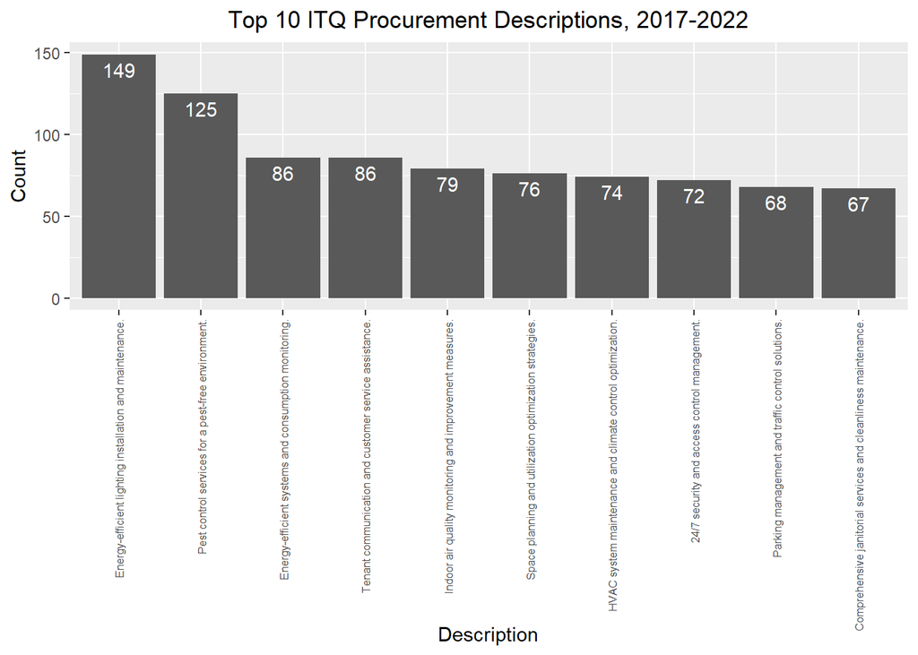

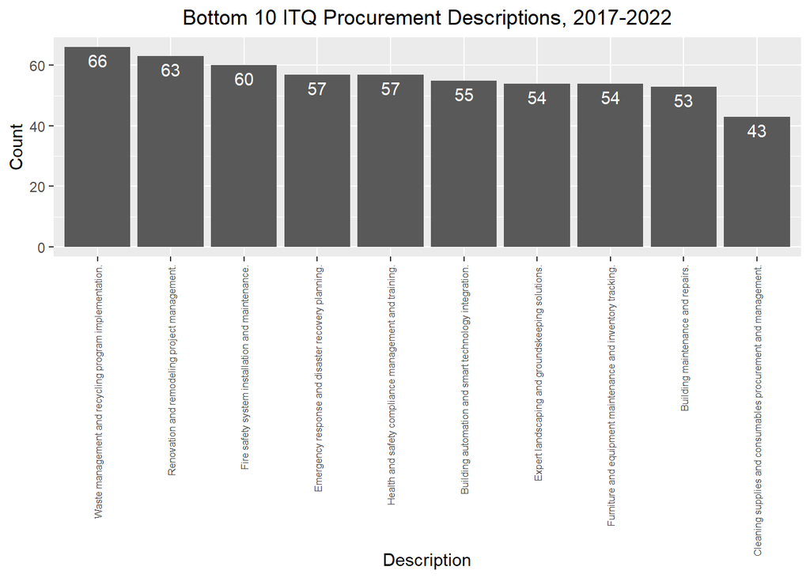

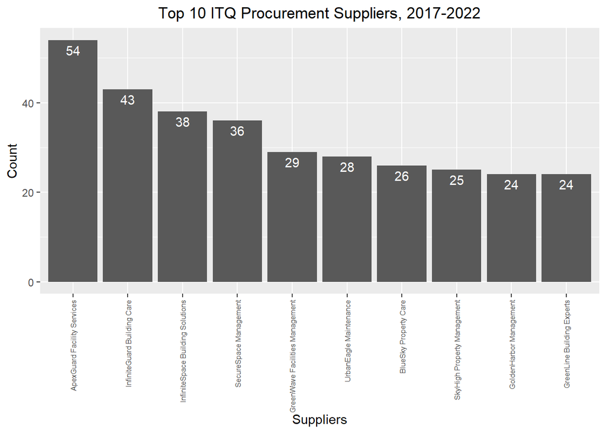

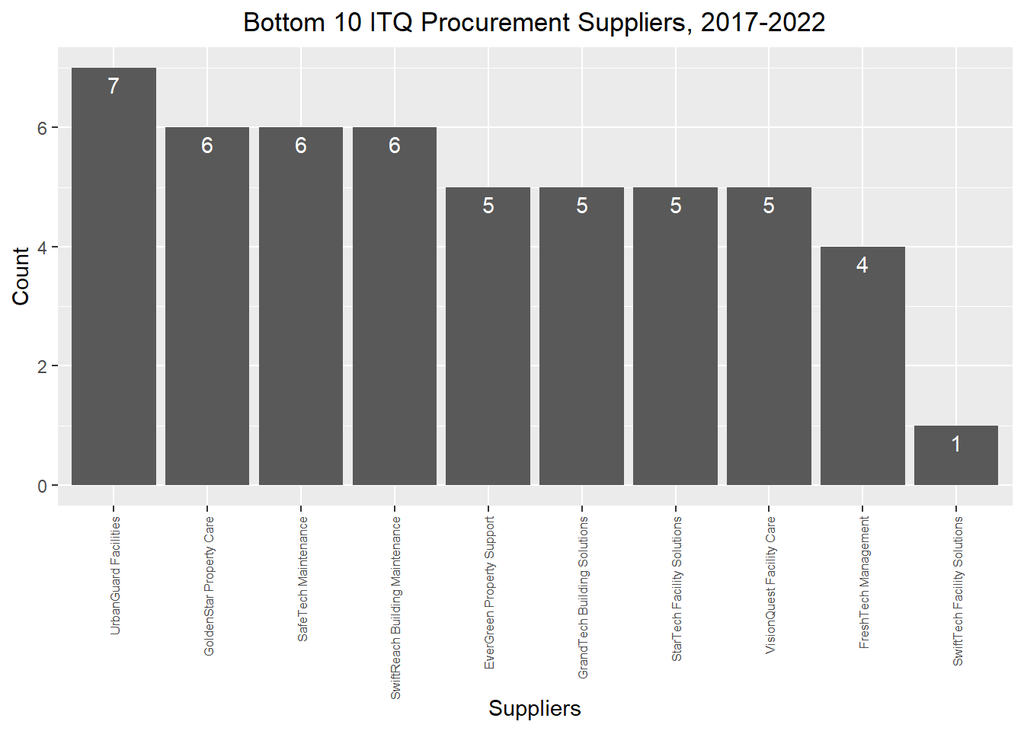

##Scatterplots #Agency-Supplier

```
##                                                       Agency
##  Agency for Cultural Preservation and Heritage           : 96
##  Commission for Ethical Governance                       : 96
##  Department of Advanced Technological Research           : 96
##  Institute for Social Justice and Equality               : 96
##  Ministry of Strategic Economic Planning                 : 96
##  Office of International Relations and Diplomatic Affairs: 96
##  (Other)                                                 :773
##                           Supplier         Freq             Total
##  AlphaStone Property Support  :  15   Min.   :  1.000   Min.   : 115.0
##  AlphaWave Property Solutions :  15   1st Qu.:  2.000   1st Qu.: 326.0
##  ApexGuard Facility Services  :  15   Median :  4.000   Median : 485.0
##  BlueBreeze Facility Solutions:  15   Mean   :  5.187   Mean   : 483.7
##  BlueCrest Facility Support   :  15   3rd Qu.:  7.000   3rd Qu.: 568.0
##  BlueSky Property Care        :  15   Max.   :177.000   Max.   :1050.0
##  (Other)                      :1259
##       Perc
##  Min.   : 0.1706
##  1st Qu.: 0.6135
##  Median : 0.9203
##  Mean   : 1.1119
##  3rd Qu.: 1.4286
##  Max.   :31.8919
##
```

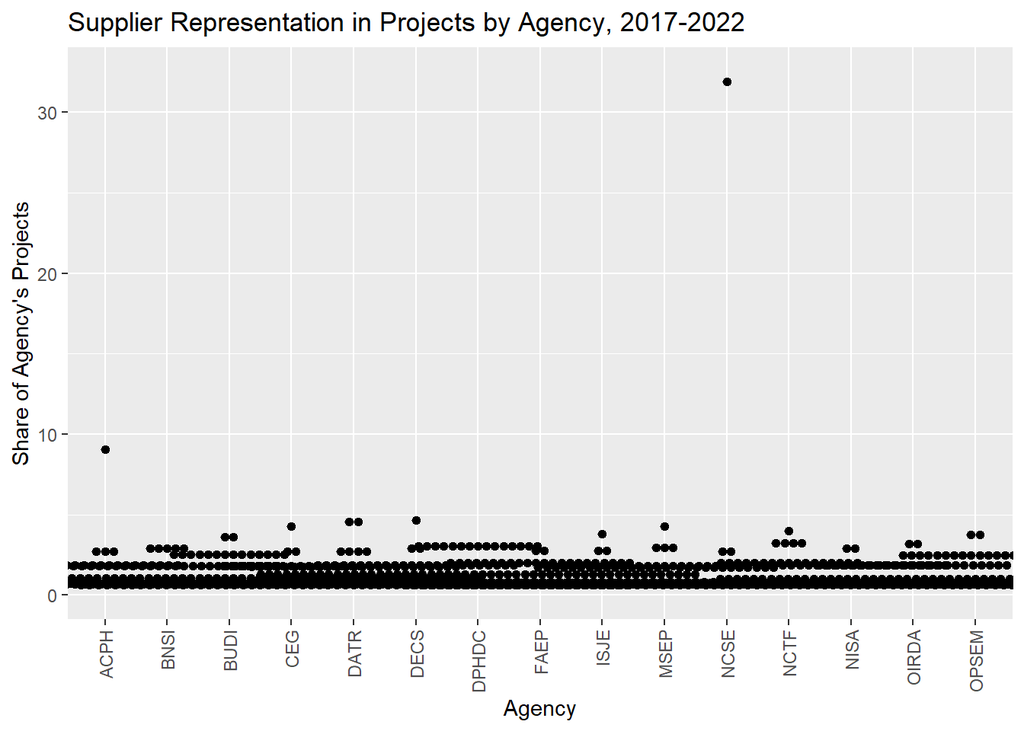

|  | Agency | Supplier | Freq | Total | Perc |
| --- | --- | --- | --- | --- | --- |
| 959 | National Commission for Space Exploration | SecureSpace Management | 177 | 555 | 31.89189 |

| Agency | Supplier | Freq | Total | Perc |
| --- | --- | --- | --- | --- |
| National Commission for Space Exploration | SecureSpace Management | 177 | 555 | 31.8918919 |
| National Commission for Space Exploration | InfiniteGuard Building Care | 15 | 555 | 2.7027027 |
| National Commission for Space Exploration | InfiniteSpace Building Solutions | 15 | 555 | 2.7027027 |
| National Commission for Space Exploration | BlueSky Property Care | 12 | 555 | 2.1621622 |
| National Commission for Space Exploration | GoldenHarbor Management | 11 | 555 | 1.9819820 |
| National Commission for Space Exploration | GreenLine Building Experts | 9 | 555 | 1.6216216 |
| National Commission for Space Exploration | ApexGuard Facility Services | 8 | 555 | 1.4414414 |
| National Commission for Space Exploration | GoldenGate Facility Masters | 8 | 555 | 1.4414414 |
| National Commission for Space Exploration | HorizonHarbor Property Services | 8 | 555 | 1.4414414 |
| National Commission for Space Exploration | TrueView Management | 8 | 555 | 1.4414414 |

[output cut: 81 more lines]

```
##                   24/7 security and access control management.
##                                                             10
##          Building automation and smart technology integration.
##                                                              4
##                              Building maintenance and repairs.
##                                                             11
##  Cleaning supplies and consumables procurement and management.
##                                                              0
## Comprehensive janitorial services and cleanliness maintenance.
##                                                              4
##             Emergency response and disaster recovery planning.
##                                                             14
##        Energy-efficient lighting installation and maintenance.
##                                                             20
##           Energy-efficient systems and consumption monitoring.
##                                                             10
##               Expert landscaping and groundskeeping solutions.
##                                                              8
##               Fire safety system installation and maintenance.
##                                                             10
##    Furniture and equipment maintenance and inventory tracking.
##                                                             10
##          Health and safety compliance management and training.
##                                                              7
##      HVAC system maintenance and climate control optimization.
##                                                              8
##        Indoor air quality monitoring and improvement measures.
##                                                              9
##              Parking management and traffic control solutions.
##                                                              7
##             Pest control services for a pest-free environment.
##                                                             13
##                  Renovation and remodeling project management.
##                                                              9
##        Space planning and utilization optimization strategies.
##                                                              8
##          Tenant communication and customer service assistance.
##                                                              8
##         Waste management and recycling program implementation.
##                                                              7
```

| Description | Freq |
| --- | --- |
| Energy-efficient lighting installation and maintenance. | 20 |
| Emergency response and disaster recovery planning. | 14 |
| Pest control services for a pest-free environment. | 13 |
| Building maintenance and repairs. | 11 |
| 24/7 security and access control management. | 10 |
| Energy-efficient systems and consumption monitoring. | 10 |
| Fire safety system installation and maintenance. | 10 |
| Furniture and equipment maintenance and inventory tracking. | 10 |
| Indoor air quality monitoring and improvement measures. | 9 |
| Renovation and remodeling project management. | 9 |

[output cut: 9 more lines]

#Agency-Description

```
##                                                   Agency
##  Agency for Cultural Preservation and Heritage       : 20
##  Bureau of National Security and Intelligence        : 20
##  Bureau of Urban Development and Infrastructure      : 20
##  Commission for Ethical Governance                   : 20
##  Department of Advanced Technological Research       : 20
##  Department of Energy Conservation and Sustainability: 20
##  (Other)                                             :179
##                                                          Description
##  24/7 security and access control management.                  : 15
##  Building automation and smart technology integration.         : 15
##  Building maintenance and repairs.                             : 15
##  Cleaning supplies and consumables procurement and management. : 15
##  Comprehensive janitorial services and cleanliness maintenance.: 15
##  Emergency response and disaster recovery planning.            : 15
##  (Other)                                                       :209
##       Freq           Total             Perc
##  Min.   :  1.0   Min.   : 115.0   Min.   : 0.8696
##  1st Qu.: 13.0   1st Qu.: 277.0   1st Qu.: 3.8285
##  Median : 21.0   Median : 485.0   Median : 4.5852
##  Mean   : 23.4   Mean   : 467.6   Mean   : 5.0167
##  3rd Qu.: 29.0   3rd Qu.: 568.0   3rd Qu.: 5.4435
##  Max.   :105.0   Max.   :1050.0   Max.   :13.7184
##
```

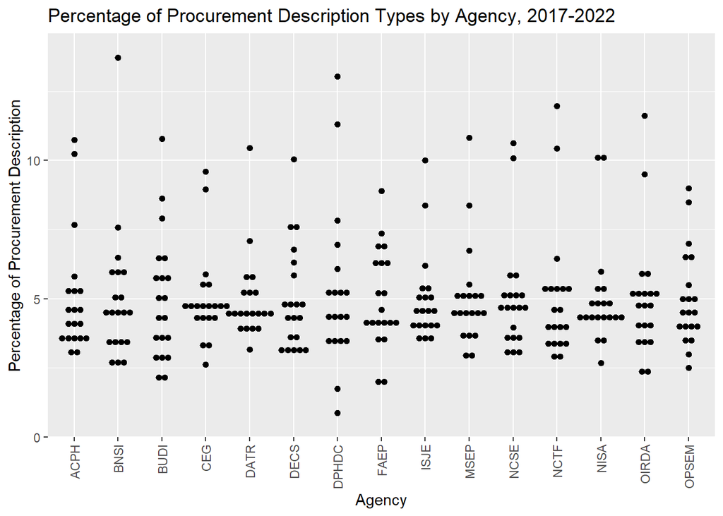

#Supplier-Description

```
##                           Supplier
##  ApexGuard Facility Services  :  20
##  BlueBreeze Facility Solutions:  20
##  BlueReach Property Solutions :  20
##  EverPro Property Support     :  20
##  GoldenHarbor Management      :  20
##  GrandView Facilities Group   :  20
##  (Other)                      :1646
##                                                   Description
##  Pest control services for a pest-free environment.     :  98
##  Energy-efficient lighting installation and maintenance.:  97
##  Indoor air quality monitoring and improvement measures.:  94
##  Expert landscaping and groundskeeping solutions.       :  93
##  Fire safety system installation and maintenance.       :  93
##  Parking management and traffic control solutions.      :  92
##  (Other)                                                :1199
##       Freq             Total             Perc
##  Min.   :  1.000   Min.   : 17.00   Min.   : 0.4202
##  1st Qu.:  2.000   1st Qu.: 51.00   1st Qu.: 3.2609
##  Median :  3.000   Median : 60.00   Median : 4.9180
##  Mean   :  3.962   Mean   : 72.94   Mean   : 5.5493
##  3rd Qu.:  5.000   3rd Qu.: 95.00   3rd Qu.: 7.0423
##  Max.   :190.000   Max.   :238.00   Max.   :79.8319
##
```

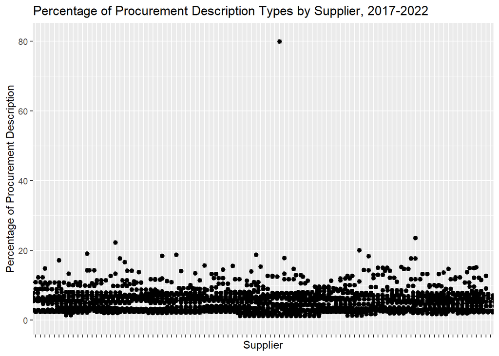

|  | Supplier | Description | Freq | Total | Perc |
| --- | --- | --- | --- | --- | --- |
| 941 | InfiniteSpace Building Solutions | Cleaning supplies and consumables procurement and management. | 190 | 238 | 79.83193 |

| Supplier | Description | Freq | Total | Perc |
| --- | --- | --- | --- | --- |
| InfiniteSpace Building Solutions | Cleaning supplies and consumables procurement and management. | 190 | 238 | 79.8319328 |
| InfiniteSpace Building Solutions | Building automation and smart technology integration. | 5 | 238 | 2.1008403 |
| InfiniteSpace Building Solutions | Building maintenance and repairs. | 5 | 238 | 2.1008403 |
| InfiniteSpace Building Solutions | Emergency response and disaster recovery planning. | 4 | 238 | 1.6806723 |
| InfiniteSpace Building Solutions | Energy-efficient systems and consumption monitoring. | 4 | 238 | 1.6806723 |
| InfiniteSpace Building Solutions | Fire safety system installation and maintenance. | 4 | 238 | 1.6806723 |
| InfiniteSpace Building Solutions | Comprehensive janitorial services and cleanliness maintenance. | 3 | 238 | 1.2605042 |
| InfiniteSpace Building Solutions | HVAC system maintenance and climate control optimization. | 3 | 238 | 1.2605042 |
| InfiniteSpace Building Solutions | Renovation and remodeling project management. | 3 | 238 | 1.2605042 |
| InfiniteSpace Building Solutions | 24/7 security and access control management. | 2 | 238 | 0.8403361 |

[output cut: 9 more lines]